# Statistical Inference - Assignment

Petra Mala

26/10/2019

# Review criteria

- Did you show where the distribution is centered at and compare it to the theoretical center of the distribution?
- Did you show how variable it is and compare it to the theoretical variance of the distribution?
- Did you perform an exploratory data analysis of at least a single plot or table highlighting basic features of the data?
- Did the student perform some relevant confidence intervals and/or tests?
- Were the results of the tests and/or intervals interpreted in the context of the problem correctly?
- Did the student describe the assumptions needed for their conclusions?

# Part 1: Simulation Exercise Instructionsless

In this project you will investigate the exponential distribution in R and compare it with the Central Limit Theorem. The exponential distribution can be simulated in R with rexp(n, lambda) where lambda is the rate parameter. The mean of exponential distribution is 1/lambda and the standard deviation is also 1/lambda. Set lambda = 0.2 for all of the simulations. You will investigate the distribution of averages of 40 exponentials. Note that you will need to do a thousand simulations.

Illustrate via simulation and associated explanatory text the properties of the distribution of the mean of 40 exponentials. You should

1. Show the sample mean and compare it to the theoretical mean of the distribution.
2. Show how variable the sample is (via variance) and compare it to the theoretical variance of the distribution.
3. Show that the distribution is approximately normal.

In point 3, focus on the difference between the distribution of a large collection of random exponentials and the distribution of a large collection of averages of 40 exponentials.

```r
library(ggplot2)
lambda <- 0.2
n <- 40
no <- 1000
```

```r
set.seed(250)
no_matrix <- matrix(rexp(no*n, rate=lambda),no,n)
no_mean <- rowMeans(no_matrix)
```

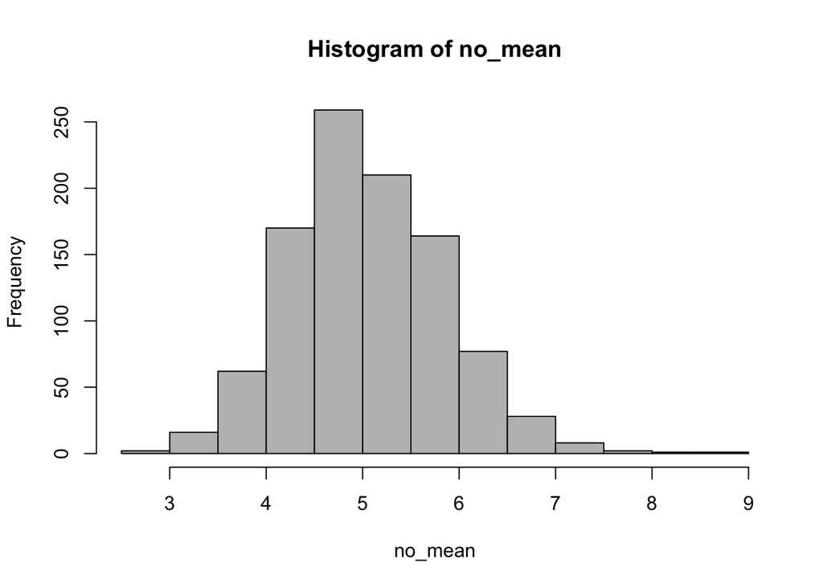

```r
hist(no_mean,col="grey")
```

```r
mmean <- mean(no_mean)
lambda_mean <- 1/lambda
no_var <- var(no_mean)
var <- (1/lambda)^2/n
no_var
```

```
## [1] 0.6354333
```

```r
## [1] 0.6354333
var
```

```
## [1] 0.625
```

```r
## [1] 0.625
```

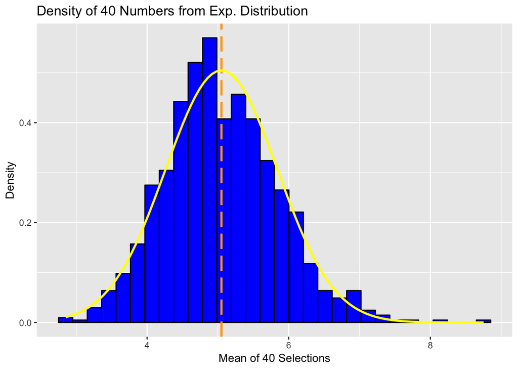

```r
#Normal Distribution
#Comparison Normal Distribution / Sample Data
plotdata <- data.frame(no_mean);
plot1 <- ggplot(plotdata, aes(x =no_mean))
plot1 <- plot1 +geom_histogram(aes(y=..density..), colour="black",fill = "blue")
plot1<-plot1+labs(title="Density of 40 Numbers from Exp. Distribution", x="Mean of 40 Selections", y="Density")
plot1<-plot1 +geom_vline(xintercept=mmean,size=1.0, color="orange",linetype = "longdash")
plot1<-plot1 +stat_function(fun=dnorm,args=list( mean=mmean, sd=sqrt(var)),color = "yellow", size = 1.0)
print(plot1)
```

```r
## `stat_bin()` using `bins = 30`. Pick better value with `binwidth`.
```

```r
#Variances and CI
CI <- round(mean(no_mean)+c(-1,1)*1.96*sd(no_mean)/sqrt(n),3)
CCI <- lambda_mean+c(-1,1)*1.96*sqrt(var)/sqrt(n)
CI
```

```
## [1] 4.803 5.297
```

```r
## [1] 4.803 5.297
CCI
```

```
## [1] 4.755 5.245
```

```r
## [1] 4.755 5.245
```

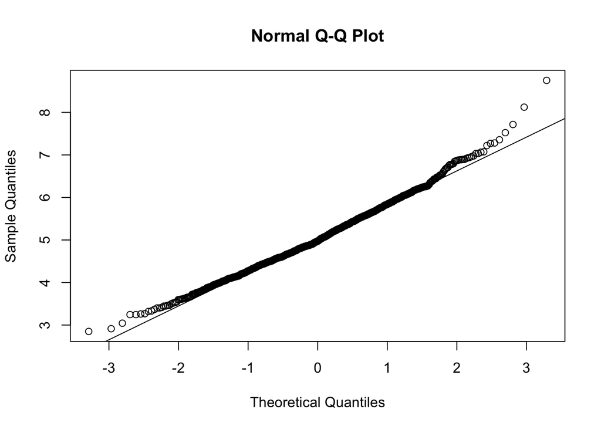

```r
# Plot for Quantiles
qqnorm(no_mean)
qqline(no_mean)
```

2. Sample Project Report Structure

Of course, there are multiple ways one could structure a report to address the requirements above. However, the more clearly you pose and answer each question, the easier it will be for reviewers to clearly identify and evaluate your work.

A sample set of headings that could be used to guide the creation of your report might be:

- Title (give an appropriate title) and Author Name
- Overview: In a few (2-3) sentences explain what is going to be reported on.
- Simulations: Include English explanations of the simulations you ran, with the accompanying R code. Your explanations should make clear what the R code accomplishes.
- Sample Mean versus Theoretical Mean: Include figures with titles. In the figures, highlight the means you are comparing. Include text that explains the figures and what is shown on them, and provides appropriate numbers.
- Sample Variance versus Theoretical Variance: Include figures (output from R) with titles. Highlight the variances you are comparing. Include text that explains your understanding of the differences of the variances.
- Distribution: Via figures and text, explain how one can tell the distribution is approximately normal.

Part 2: Basic Inferential Data Analysis Instructionsless Now in the second portion of the project, we’re going to analyze the ToothGrowth data in the R datasets package.

1. Load the ToothGrowth data and perform some basic exploratory data analyses
2. Provide a basic summary of the data. 3.Use confidence intervals and/or hypothesis tests to compare tooth growth by supp and dose. (Only use the techniques from class, even if there’s other approaches worth considering) 4.State your conclusions and the assumptions needed for your conclusions.

```r
# Required packages:
library(ggplot2)
```

1. Load the ToothGrowth data and perform some basic exploratory data analyses

```r
# Load the data ToothGrowth
data(ToothGrowth)
```

```r
# Look at the structure of the data
str(ToothGrowth)
```

```
## 'data.frame':    60 obs. of  3 variables:
##  $ len : num  4.2 11.5 7.3 5.8 6.4 10 11.2 11.2 5.2 7 ...
##  $ supp: Factor w/ 2 levels "OJ","VC": 2 2 2 2 2 2 2 2 2 2 ...
##  $ dose: num  0.5 0.5 0.5 0.5 0.5 0.5 0.5 0.5 0.5 0.5 ...
```

```r
head(ToothGrowth, 5)
```

```
##    len supp dose
## 1  4.2   VC  0.5
## 2 11.5   VC  0.5
## 3  7.3   VC  0.5
## 4  5.8   VC  0.5
## 5  6.4   VC  0.5
```

2. Provide a basic summary of the data.

```r
# Look at the summary of the data
summary(ToothGrowth)
```

```
##       len        supp         dose
##  Min.   : 4.20   OJ:30   Min.   :0.500
##  1st Qu.:13.07   VC:30   1st Qu.:0.500
##  Median :19.25           Median :1.000
##  Mean   :18.81           Mean   :1.167
##  3rd Qu.:25.27           3rd Qu.:2.000
##  Max.   :33.90           Max.   :2.000
```

```r
tapply(ToothGrowth$len,ToothGrowth$supp, mean)
```

```
##       OJ       VC
## 20.66333 16.96333
```

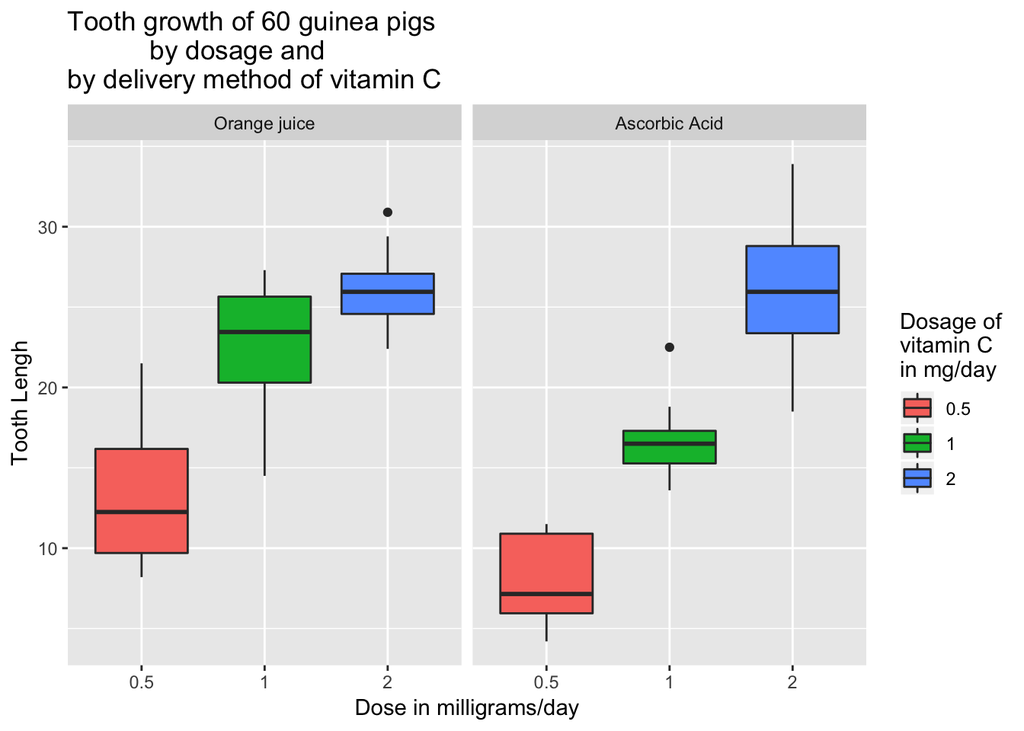

```r
ggplot(ToothGrowth, aes(factor(dose), len, fill = factor(dose))) +
      geom_boxplot() +
      # facet_grid(.~supp)+
      facet_grid(.~supp, labeller = as_labeller(
            c("OJ" = "Orange juice",
              "VC" = "Ascorbic Acid"))) +
      labs(title = "Tooth growth of 60 guinea pigs
           by dosage and\nby delivery method of vitamin C",
           x = "Dose in milligrams/day",
           y = "Tooth Lengh") +
      scale_fill_discrete(name = "Dosage of\nvitamin C\nin mg/day")
```

3. Use confidence intervals and/or hypothesis tests to compare tooth growth by supp and dose.

```r
# Comparison by delivery method for the same dosage
t05 <- t.test(len ~ supp,
       data = rbind(ToothGrowth[(ToothGrowth$dose == 0.5) &
                                      (ToothGrowth$supp == "OJ"),],
                    ToothGrowth[(ToothGrowth$dose == 0.5) &
                                      (ToothGrowth$supp == "VC"),]),
       var.equal = FALSE)

t1 <- t.test(len ~ supp,
       data = rbind(ToothGrowth[(ToothGrowth$dose == 1) &
                                      (ToothGrowth$supp == "OJ"),],
                    ToothGrowth[(ToothGrowth$dose == 1) &
                                      (ToothGrowth$supp == "VC"),]),
       var.equal = FALSE)

t2 <- t.test(len ~ supp,
       data = rbind(ToothGrowth[(ToothGrowth$dose == 2) &
                                      (ToothGrowth$supp == "OJ"),],
                    ToothGrowth[(ToothGrowth$dose == 2) &
                                      (ToothGrowth$supp == "VC"),]),
       var.equal = FALSE)
```

```r
# Make summary of the conducted t.tests, which compare the delivery methods by dosage
# take p-values and CI
summaryBYsupp <- data.frame(
      "p-value" = c(t05$p.value, t1$p.value, t2$p.value),
      "Conf.Low" = c(t05$conf.int[1],t1$conf.int[1], t2$conf.int[1]),
      "Conf.High" = c(t05$conf.int[2],t1$conf.int[2], t2$conf.int[2]),
      row.names = c("Dosage .05","Dosage 1","Dosage 2"))
```

```r
# Show the data table
summaryBYsupp
```

```
##                p.value  Conf.Low Conf.High
## Dosage .05 0.006358607  1.719057  8.780943
## Dosage 1   0.001038376  2.802148  9.057852
## Dosage 2   0.963851589 -3.798070  3.638070
```

4. State your conclusions and the assumptions needed for your conclusions.

With 95% confidence we reject the null hypothesis, stating that there is no difference in the tooth growth by the delivery method for .5 and 1 milligrams/day. We observe p-values less than the treshold of .05 and the confidence levels don’t include 0. So, for dosage of .5 milligrams/day and 1 milligrams/day does matter the delivery method. With 95% confidence we fail to reject the null hypothesis, stating that there is no difference in the tooth growth by the delivery method for 2 milligrams/day. We observe p-values more than the treshold of .05 and the confidence levels include 0. So, for dosage of 2 milligrams/day the delivery method doesn’t matter.